# Manipulation de textes avec R

Svetlana Yatsyk

2024-02-07

# Importation et exportation de données

L’analyse en R commence toujours par **l’importation de données**. Mais **où** va-t-on les importer ?

## La répertoire de travail

La «répertoire de travail» (ou «working directory») dans R est le dossier sur votre ordinateur où R cherche et sauvegarde les fichiers par défaut. Lorsque vous lancez R ou RStudio, il démarre avec un répertoire de travail spécifique, qui est généralement le dossier où se trouve votre script R.

Pour savoir dans quel répertoire de travail on se trouve :

```
## [1] "/Users/sy/Documents/GitHub/textometry_Paris-Saclay/S_2"
```

Pour changer le répertoire :

Pour copier le chemin d’un fichier, sélectionner le fichier, puis **Option + Command + C** (Mac) ou **Ctrl + Shift + C** (Windows).

`/Users/sy/Documents/GitHub/textometry_Paris-Saclay/S_2` est le chemin de dossier **absolu**. Il s’agit de l’adresse exacte du fichier sur mon ordinateur.

La création d’un **projet RStudio** présente un certain nombre d’avantages en termes de navigation entre les fichiers :

- Lorsque vous travaillez dans un projet R, tous les chemins de fichiers sont définis **relativement au répertoire de travail** du projet. Cela signifie que vous pouvez utiliser des chemins de fichiers courts et simples sans avoir à spécifier un chemin absolu.
- Par conséquent, votre projet devient plus **portable**. Vous pouvez le déplacer vers un autre ordinateur ou le partager avec d’autres personnes sans avoir à reconfigurer les chemins de fichiers.

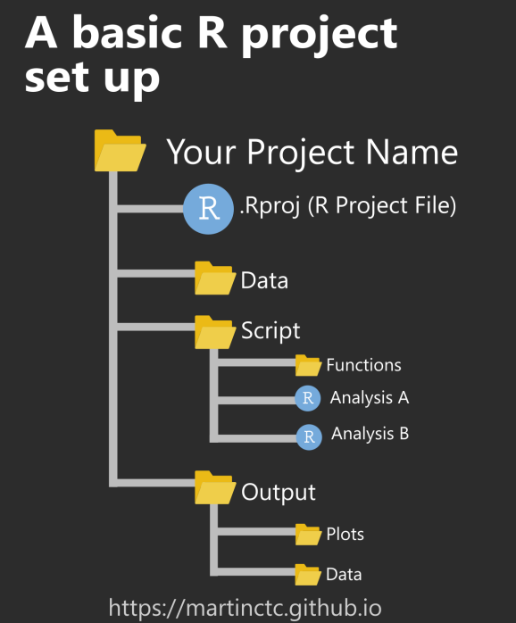

Structure basique pour les projets. Source: https://martinctc.github.io/.

Il est donc fortement recommandé de créer un projet pour chaque étude effectuée avec R en respectant l’arborescence présentée sur l’image ci-dessus.

## Manipulation de données tabulaires

Pour lire des données tabulaires, utilisez `read.table()` (pour .tab et .tsv) et `read.csv()` (pour .csv).

### tsv, tab

```
##                                                                     quote
## 1 Genius is one percent inspiration and ninety-nine percent perspiration.
## 2                                 You can observe a lot just by watching.
## 3                            A house divided against itself cannot stand.
## 4                    Difficulties increase the nearer we get to the goal.
## 5                                  Fate is in your hands and no one elses
## 6                                        Be the chief but never the lord.
```

La fonction `head()` est utilisée pour afficher les premières lignes d’un objet en R. Par défaut, elle retourne **les six premières lignes**. L’opération de sous-ensemble `[1]` indique à R de prendre uniquement la première colonne.

```
## [1] "Abraham Lincoln"
```

```
## [1] "Be the chief but never the lord."
```

```
## [1] "A house divided against itself cannot stand."
## [2] "Difficulties increase the nearer we get to the goal."
## [3] "Fate is in your hands and no one elses"
```

#### **Exercice :**

> **trouver et afficher une citation de Sénèque, Virgile, Plutarque, Bouddha, Confucius.**

### csv

`read.csv()` fait la meme chose, mais définit automatiquement les paramètres pour lire les fichiers .csv.

## Manipulation de données textuelles

### txt

Utilisez `readLines()` pour lire des fichiers texte. Cette fonction est utilisée pour lire du texte à partir d’une source de données (comme un fichier) et renvoie un vecteur dont chaque élément représente une ligne de texte du fichier. L’argument `n` détermine le nombre de lignes à lire. NB! **L’indexation en R commence à 1** (tandis que celle de Python commence à 0).

Pour voir le contenu d’un objet créé, il suffit de taper son nom dans la console et d’appuyer sur la touche Entrée.

#### **Exercice :**

> **créer un objet ne contenant que le premier chapitre du livre de la Genèse.**

### doc

**Il est préférable d’éviter les fichiers Word**, en les convertissant en dehors de R en `.txt`. Sinon, il faut installer la bibliothèque `officer` et utiliser la fonction `read_docx()`.

[output not shown]

[output not shown]

### pdf

**Il est préférable d’éviter les fichiers PDF** aussi. Si cela est indispensable, il convient d’utiliser la bibliothèque `pdftools` pour l’importation.

```
## Using poppler version 22.02.0
```

```
## [1] "Thomas Hegghammer"
```

En R, le symbole `$` est utilisé pour **accéder aux éléments** d’une liste ou aux colonnes d’un dataframe **par leur nom**. Cela permet de sélectionner une colonne spécifique d’un dataframe ou un élément spécifique d’une liste en utilisant le nom de cet élément.

Au lieu de numéroter les colonnes de `quotes`, nous pourrions simplement les appeler par leur nom !

```
##   [1] "Genius is one percent inspiration and ninety-nine percent perspiration."
##   [2] "You can observe a lot just by watching."
##   [3] "A house divided against itself cannot stand."
##   [4] "Difficulties increase the nearer we get to the goal."
##   [5] "Fate is in your hands and no one elses"
##   [6] "Be the chief but never the lord."
##   [7] "Nothing happens unless first we dream."
##   [8] "Well begun is half done."
##   [9] "Life is a learning experience, only if you learn."
##  [10] "Self-complacency is fatal to progress."
##  [11] "Peace comes from within. Do not seek it without."
##  [12] "What you give is what you get."
##  [13] "We can only learn to love by loving."
##  [14] "Life is change. Growth is optional. Choose wisely."
##  [15] "Youll see it when you believe it.\tWayne Dyer\nTo lead people walk behind them.\tLao Tzu\nHaving nothing, nothing can he lose.\tWilliam Shakespeare\nTrouble is only opportunity in work clothes.\tHenry J. Kaiser\nA rolling stone gathers no moss.\tPublilius Syrus\nIdeas are the beginning poi…
```

[output cut: 225 more lines]

#### **Exercice :**

> **afficher ligne 30 de la colonne “source”.**

Pour reconnaître un fichier PDF qui n’a pas été OCRsé, il faut installer la bibliothèque `tesseract` et télécharger la langue requise.

```
## [1] "/Users/sy/Library/Application Support/tesseract5/tessdata/ita.traineddata"
```

```
## Converting page 2 to Agiografi_e_notai_2.png... done!
```

```
## i
## 206 ALESSANDRA BARTOLOMEI ROMAGNOLI AGIOGRAFI E NOTAI 207
## ME SANE divozione a lui, che quasi niuno era che in alcuna preziose, perché, data la notevole mobilità cui li costringe la
## avversità fosse, che ad altro santo che a lui si botasse, e professione, essi hanno orizzonti ampi, non strettamente locali,
## chiamoronlo e chiamano si Ciappelletto, ed affermano, molti e possono documentare, forse meglio di chiunque altro,
## miracoli Iddio aver mostrati per lui e mostrare tutto giorno a l'estensione della fama pubblica del candidato, un capitolo
## chi divotamente si raccomanda a lui» (4). importante in sede di giudizio (7). La deposizione di un notaio
## Viene da chiedersi se l’eroe sacrilego di Boccaccio possa | ha un valore pregnante, proprio perché il notaio detiene, quasi
## assurgere a modello di un nascente spirito critico razionalista e come « un suo connotato stabile, di per sé qualificante » (8), la
## laico, che vedrebbe proprio nei notai, depositari di compe- bona fides, il rispetto assoluto della verità di un fatto, che deve
## tenze tecnico-giuridiche con ambizioni di oggettività scienti- essere riportato senza nulla togliere o aggiungere. E in realtà,
## fica, gli agenti ideali di nuovi valori e visioni del mondo, in le testimonianze dei notai si sottolineano quasi sempre per la
## palese contrasto con la credulità diffusa del volgo. Ma Boc- precisione e la coerenza del racconto, in cui una devozione
## caccio in realtà non mette in discussione la possibilità dei indiscussa si mescola alla sensibilità, peculiare del mestiere, per
## miracoli, si limita a porre il grande problema della finzione, i problemi di correttezza procedurale. Nel processo di Nicola,
## invita all'esercizio critico all’atto del riconoscimento. Semmai, ser Accorso, legista di Tolentino, nel riferire un miracolo di
## l’intento satirico diventa ancora più sottile e corrosivo proprio | liberazione di cui non è stato testimone oculare, ha cura di
## perché investe la credibilità di uno dei pilastri fondanti l’or- precisare che esso gli è stato notificato dall'amico e collega
## dine e la stabilità dei rapporti sociali, la figura del notaio | Bernardo in lettere « scripte manu dicti domini et sigillate
## appunto, che di quest'ordine è il simbolo, in quanto « sovrano sigillo eiusdem » (9), e che ha potuto autenticare con certezza
## dispensatore di autenticità [...] depositario riconosciuto della la scrittura e il sigillo perché egli era stato un suo stretto
## publica fides » (5). Nella società medioevale è al notariato che collaboratore. L'attività dei notai non si limita del resto alla
## compete — quasi carisma stesso della categoria — la titolarità fase processuale, che rappresenta solo il punto di arrivo di un
## a produrre testimonianze irrecusabili. lungo lavoro preparatorio di stratificazione della memoria. Essi
## Se scorriamo i processi di canonizzazione trecenteschi, la i hanno parte attiva nella compilazione delle liste dei miracoli
## casistica di notai e legisti chiamati a deporre quali diretti che poi saranno vagliate nel corso della istruttoria. Lo stesso
## beneficiari o testimoni di eventi prodigiosi è molto folta (6), a Bernardo Appillatterra ricorda che quando si trovava a Fi-
## confermare la trasversalità socio-culturale della fede nel potere renze, avendo sentito suonare le campane della chiesa agosti-
## taumaturgico dei santi. Le loro testimonianze sono in genere
## | (7) Il notaio di Tolentino Berardus Appillatterre, amico personale di san
## 6 ion nen pie er zrim epr vermi rn
## Row wr seni e riglger tr si cronisti della Marca trevigiana nell'età di Ezzelino da 2 (AR ivinitae itinerante, perché il pubblico officialis citi in carica per un
## die corso: del pioli di Cullen i IRR. aa! tempo breve e deve poi trasferirsi ad esercitare in un altro comune. Berardus era stato
## furono chiamati a deporre 9 notai, 9 suris periti, 3 doctores legum. Cfr. Il processo per i i cessate Susa ai acri Pristina tram siano
## la canonizzazione di S. Nicola da Tolentino, ed. N. OccHIONI, Roma 1984 (Collection de pmi "Oporto NT GHgo, E
## i l’Ecole frangaise de Rome, 74) = PC Nicola da Tolentino. I notai generalmente pera Les orafi pi spici rn pigra ; sn de iran ng
## , compivano studi diversi da quelli che portavano al dottorato, percorsi invece da iuris i lag incipit Aa pos gi predire sere Miti Cioni
## > data doctors legum, Non FARE) chiamati domini, ma godevano della qualificazione doctor le dA attivo come pubblico officialis in pri località dell’Italia pesitrale
## di ser. Alcuni di loro erano dei mercanti che cercavano la qualifica di notai per (ibid. hi 12). i
## attendere a un'attività commerciale sempre più complessa. Nel processo di Nicola da gf ArnaLpi, Studi sui cronisti, cit., p. 117
## quattro notai sono detti anche mercatores (ibid., pp. 64, 310, 318, 423). (9) PC Nicola da'Tolentio; pi. 115. i
## I
## I
```

### images

Les images peuvent également être reconnues par `tesseract`, mais la précision de la transcription dépend à la fois de la qualité de l’image et de la police de caractères.

```
## [1] "/Users/sy/Library/Application Support/tesseract5/tessdata/fra.traineddata"
```

```
## fi : OR J'EN T ALES ALAN RE a
## ki 4 tilz-hommes, foldats & autres de noftre compagnie: les principaux defquels
## ESS eftoyent.Le fasnommé Cheualier de Seureauec fa galliotre;le Sieur de Mont- Aom déprir-
## >= | cnard Daulphinois, homme d'armes dela compagnie dufufdiét fieur Conte Done Ca.
## 4 de Tende, auecvne fregatte pour nous accompagner & rapporter de noz nou Le ol
## uelles, Je Capitaine Gofte lieutenant del Ambañladeur für fes galleressvn fien 4 ni
## l nepueu nommé Erafme, Le fieur de fainét Veran, frere de Madame d’Ara- der.
## mont, le ieune Baron de Loudon , & leSieur de Fleurycous deuxnepueux de
##
## | 1 Ambañdeur le Cheuallier de Magliane, lefeigneur de Cotignac valler de
##
## | chäbré ordinaire du Roy, lequel pour auoir forc lénguemétvoiagé &negotié ns
## LE en Leuärpour RL MA Pr A Led Atameney fr Ame ae
## * : baffadeur.en chef, (Mais neantinoïns depuis ayant oblié l'honneur &lebien
##
## n ee FE Cargnaccbiart
## ne L qu'il auoit receu du Roy fonfouuerain Seigneur & de: la coronnede France, L' dr die”
## . contre ledeuoir de fideliré qui luycommandoir, s'eftretiré auec le Roy d'E- Far tee
## fur Î fPagne, le Seigneur de Virailh auffi valler dechambreordinaire du Roysgen sé Same
## . : tilhomme doéte & de finguliere experience;lequel pour auoir la langue Theu + pose
## . l tonique outre la Latine & quelques autres vulgaires fort familiere a depuis Ra Epagre
## ** efté par plufeurs fois foubz le regne & commandementduRoy Henry hon-
## +. | norablement & heureufemét employéen charges grandes & honnorablesau
## 24 : presdes Er & Potentas de la Germanie & du facré Empire, trois gentilz-
## # à hommes déBafcoigne freres nommez: Iueufes;le Sieur de\Sainéte Marie, le
## LE Sieur de la Motte autremenr Chafteau Regnaud, les Cappitaines la Caftelle, Æ
## Se. Barges,& Barthelemy d'Auignon Guillaume de Grantrye nepueu de Mon-
## par fieur de Laubefpine Aprefent delegué &enuoyéen Conftantinople ainfique
## a Iesautres Ambafadeurs ,vn mien nepueu nommé Claude de Bayard »&plu-
## Re fieurs autres que ietairay-poureuiter prolixité, La reucue faiéte & renuoyé.en
## ne terre quelque bouches inutiles, les anéres leuées & les voilles defployées naui
## cs | pee par quarte de Grec vers le Northau Cap de Creo en Carhaloigne, que a Ca
## #e | es Efpagnols appellét cap de Creuzes:enapres fuyuantà Grec & Tramontane Joe
##  & | tirafmes par la mer d'Efpagne vers les Lfles Baleares , ainfi nommées par les
## FR anciens, mais des modernes Maiorque & Minorque,defquellesenpaflant fe-
## se Î rons fommaire defcription. à
## us, DES ISLES, BALEARES, APPELLEÉES DES
## TA modernes Maiorque @/ AGnorque. CHA. LIL. 3 à
## Fa BR ES Ifles Baleares ( qui furentainfi n6mées du nom de Balée com
## pa- ca RES pagnon d'Hercules)combien ce les Grecz les ayent appel lées os }
## du é Her Gimnefie,& Diodore Gimnaifes , fifont elles nommées par Love
## LE SES mariniers vulgaires Maiorque & Minorque, eftans fituéesen la
## cle mer d'Éfpagne, ou Baleare ;du nom des mefmes ifles ;les’habirans defquelles .. Le Bo
## eur ainfi qu'efcrir Vegece furérles premiers inuenteurs de la fonde. Maiorque fe- ne
## ar Ion Bordonen fon Holaire;a de circuit 48o.mille, combien que les mariniers seu Lfnde.
## el mordernes ne luy en donnenr que 200. & de largeur 100. autour de ladicte ifle nu ste
## en Ya quelques efcueilz, d'ond l'vn quieft au Mydife nomme Cabrera, & lautre Aflasres
## LE qui eità l'OccidenrDragonera. Ladiéte Iflea deux citez:Palme ds iourd huy
## 3
## ; #* #4.
## Source gallica.bnf.fr / Bibliothèque nationale de France
```

# Structure de données

Nous avons déjà constaté qu’il existe plusieurs types de données dans R, à savoir : - Nombre entier (integer) ; - Nombre à virgule flottante (numeric, également appelé double, c’est-à-dire nombre à double précision) ; - Chaîne de caractères (character) ; - Variable logique (logical) ; - Variable catégorielle (factor).

Examinons maintenant les structures qu’ils peuvent former.

## Vecteurs

Les vecteurs sont les objets les plus communs en R. Il s’agit d’une **collection d’éléments à une dimension**. Les éléments contenus dans un vecteur doivent nécessairement être **de même type**. Lorsque on a créé des objets contenant un numérique ou une chaîne de caractère, R a stocké l’information sous la forme d’un vecteur de longueur 1 (vecteur contenant un seul élément).

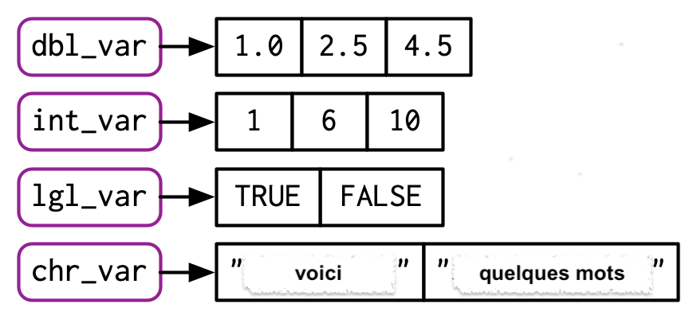

Types des vecteurs.

Pour obtenir la classe et la longueur du vecteur :

```
## [1] "character"
```

```
## [1] 3
```

Si on essaye de combiner des données de différents types dans un seul vecteur, elles seront forcées au même type :

```
## [1] 1 1 3 0
```

```
## [1] "1"    "5"    "Emma" "Owen"
```